# MCSC1 - Material do curso de Métodos Computacionais em Sistemas Complexos I

### Functions for creating arrays

#### Evenly spaced:

```python
a = np.arange(10) # 0 .. n-1 (!)
```

```python
a
```

```
array([0, 1, 2, 3, 4, 5, 6, 7, 8, 9])
```

```python
b = np.arange(1, 9, 2) #start, end (exclusive), step
b
```

```
array([1, 3, 5, 7])
```

#### by number of points:

```python
c = np.linspace(0, 1, 6) # start, end, num-points
c
```

```
array([ 0. ,  0.2,  0.4,  0.6,  0.8,  1. ])
```

```python
d = np.linspace(0, 1, 5, endpoint=False)
d
```

```
array([ 0. ,  0.2,  0.4,  0.6,  0.8])
```

```python
d = np.logspace(1,8,num=8,base=2)
d
```

```
array([   2.,    4.,    8.,   16.,   32.,   64.,  128.,  256.])
```

#### other common arrays:

```python
a = np.ones((3, 3))
a
```

```
array([[ 1.,  1.,  1.],
       [ 1.,  1.,  1.],
       [ 1.,  1.,  1.]])
```

```python
b = np.zeros((2, 2, 1))
b
```

```
array([[[ 0.],
        [ 0.]],

       [[ 0.],
        [ 0.]]])
```

```python
c = np.eye(5) #Return a 2-D array with ones on the diagonal and zeros elsewhere.
c
```

```
array([[ 1.,  0.,  0.,  0.,  0.],
       [ 0.,  1.,  0.,  0.,  0.],
       [ 0.,  0.,  1.,  0.,  0.],
       [ 0.,  0.,  0.,  1.,  0.],
       [ 0.,  0.,  0.,  0.,  1.]])
```

#### random numbers

```python
np.random.seed(1000)
```

```python
a = np.random.rand(4) #uniform [0,1]
a
```

```
array([ 0.65358959,  0.11500694,  0.95028286,  0.4821914 ])
```

```python
b = np.random.randn(4) #Gaussian \mu=0,\sigma=1
b
```

```
array([-0.30079667,  0.38947455, -0.1074373 , -0.47998308])
```

#### Basic data types

Int

```python
d = np.array([1, 2, 3])
d.dtype
```

```
dtype('int64')
```

Float

```python
d = np.array([1, 2, 3],dtype=float)
d.dtype
```

```
dtype('float64')
```

Complex

```python
d = np.array([1+2j, 3+4j, 5+6*1j])
d.dtype
```

```
dtype('complex128')
```

Bool

```python
d = np.array([True, False, False, True])
d.dtype
```

```
dtype('bool')
```

Strings

```python
d = np.array(['Bonjourś', 'Hello', 'Hallo',])
d.dtype # unicode strings max. 8 letters
```

```
dtype('<U8')
```

#### Indexing and slicing

```python
a = np.arange(10)
a
```

```
array([0, 1, 2, 3, 4, 5, 6, 7, 8, 9])
```

```python
a[0],a[2],a[-2]
```

```
(0, 2, 8)
```

- Indices begin at 0, like other Python sequences (and C/C++).
- use negative number for reverse index

#### In geral: `a[ini:end:step]` (all are *optional* args.)

```python
a[2:3] #(inclusive, exclusive)
```

```
array([2])
```

```python
a[:3]
```

```
array([0, 1, 2])
```

```python
a[3:]
```

```
array([3, 4, 5, 6, 7, 8, 9])
```

```python
a[::2]
```

```
array([0, 2, 4, 6, 8])
```

```python
a[::-1]
```

```
array([9, 8, 7, 6, 5, 4, 3, 2, 1, 0])
```

#### A small illustrated summary of NumPy indexing and slicing

[figure not shown]

### Copies and views

- A slicing operation creates a view on the original array.
- Thus the original array is not copied in memory.
- When modifying the view, the original array is modified as well.

```python
a = np.arange(10)
a
```

```
array([0, 1, 2, 3, 4, 5, 6, 7, 8, 9])
```

```python
b = a[::2]
b
```

```
array([0, 2, 4, 6, 8])
```

```python
np.may_share_memory(a, b) #Determine if two arrays might share memory
```

```
True
```

```python
b[0] = 12
b
```

```
array([12,  2,  4,  6,  8])
```

```python
a #notice that has changed
```

```
array([12,  1,  2,  3,  4,  5,  6,  7,  8,  9])
```

```python
a = np.arange(10)
c = a[::2].copy()  # force a copy
c[0]=12
a
```

```
array([0, 1, 2, 3, 4, 5, 6, 7, 8, 9])
```

```python
np.may_share_memory(a, c)
```

```
False
```

### Fancy indexing

NumPy arrays can be indexed with slices, but also with boolean or integer arrays (masks). This method is called fancy indexing.

- **It creates copies not views.**

```python
np.random.seed(3)
a = np.random.randint(0, 21, 15) #generate random integer numbers between 0 and 21 (exclusive)
a
```

```
array([10,  3,  8,  0, 19, 10, 11,  9, 10,  6,  0, 20, 12,  7, 14])
```

```python
a % 3 #notice that % is applied to each element
```

```
array([1, 0, 2, 0, 1, 1, 2, 0, 1, 0, 0, 2, 0, 1, 2])
```

```python
a % 3==0
```

```
array([False,  True, False,  True, False, False, False,  True, False,
        True,  True, False,  True, False, False], dtype=bool)
```

```python
b = a[a % 3==0] #get only the elements that %3==0
```

```python
np.may_share_memory(a, b) #notice that they don't share memory
```

```
False
```

### Indexing with an array of integers

```python
a = np.arange(0, 100, 10)
a
```

```
array([ 0, 10, 20, 30, 40, 50, 60, 70, 80, 90])
```

```python
a[[2, 3, 2, 4, 2]]
```

```
array([20, 30, 20, 40, 20])
```

##### New values can be assigned with this kind of indexing.

```python
a[[9, 7]] = -100
a
```

```
array([   0,   10,   20,   30,   40,   50,   60, -100,   80, -100])
```

### Numerical operations on arrays

#### Basic operations

- **All arithmetic operates elementwise**

```python
a = np.array([1, 2, 3, 4])
```

```python
a+1
```

```
array([2, 3, 4, 5])
```

```python
a**2
```

```
array([ 1,  4,  9, 16])
```

```python
2**a
```

```
array([ 2,  4,  8, 16])
```

```python
a = np.array([1, 2, 3, 4])
b = np.array([2, 3, 4, 5])
a-b
```

```
array([-1, -1, -1, -1])
```

```python
a = np.array([1, 2, 3, 4])
b = np.array([2, 3, 4]) #they must have the same shapes
a-b
```

```
---------------------------------------------------------------------------
ValueError                                Traceback (most recent call last)
<ipython-input-222-135ff987429c> in <module>()
      1 a = np.array([1, 2, 3, 4])
      2 b = np.array([2, 3, 4]) #they must have the same shapes
----> 3 a-b

ValueError: operands could not be broadcast together with shapes (4,) (3,)
```

#### These operations are of course much faster than if you did them in pure python

```python
a = np.arange(10000)
%timeit a + 1
```

```
4.05 µs ± 100 ns per loop (mean ± std. dev. of 7 runs, 100000 loops each)
```

```python
l = range(10000)
%timeit [i+1 for i in l]
```

```
553 µs ± 9.25 µs per loop (mean ± std. dev. of 7 runs, 1000 loops each)
```

```python
f"about {553/4.05}x faster"
```

```
'about 136.54320987654322x faster'
```

#### Array multiplication is not matrix multiplication

```python
c = np.ones((3, 3))
```

```python
c*c
```

```
array([[ 1.,  1.,  1.],
       [ 1.,  1.,  1.],
       [ 1.,  1.,  1.]])
```

```python
np.dot(c,c) #Dot product of two arrays.
```

```
array([[ 3.,  3.,  3.],
       [ 3.,  3.,  3.],
       [ 3.,  3.,  3.]])
```

#### Other operations

```python
#Comparisons:
a = np.array([1, 2, 3, 4])
b = np.array([4, 2, 2, 4])
```

[output not shown]

```python
a == b
```

```
array([False,  True, False,  True], dtype=bool)
```

```python
a > b
```

```
array([False, False,  True, False], dtype=bool)
```

for array-wise comparisons, `use array_equal`

```python
a = np.array([1, 2, 3, 4])
b = np.array([4, 2, 2, 4])
c = np.array([1, 2, 3, 4])
```

```python
np.array_equal(a, b)
```

[output not shown]

```python
np.array_equal(a, c)
```

[output not shown]

#### Transcendental functions

```python
a = np.arange(5)
```

```python
np.cos(a)
```

```
array([ 1.        ,  0.54030231, -0.41614684, -0.9899925 , -0.65364362])
```

```python
np.log(a) #it deals with infs
```

```
array([       -inf,  0.        ,  0.69314718,  1.09861229,  1.38629436])
```

```python
import math
```

```python
[math.log(x) for x in range(5)] #pure python will rise an exception
```

```
---------------------------------------------------------------------------
ValueError                                Traceback (most recent call last)
<ipython-input-242-a0fce0b0b680> in <module>()
----> 1 [math.log(x) for x in range(5)]

<ipython-input-242-a0fce0b0b680> in <listcomp>(.0)
----> 1 [math.log(x) for x in range(5)]

ValueError: math domain error
```

### Numerical operations on arrays

#### Computing sums

```python
x = np.array([1, 2, 3, 4])
x.sum()
```

```
10
```

```python
np.sum(x)
```

```
10
```

```python
x = np.array([[1, 1], [2, 2]])
x
```

```
array([[1, 1],
       [2, 2]])
```

```python
np.sum(x)
```

```
6
```

**Axis**

Most numpy functions take axis as an argument.

```python
np.sum(x,axis=0),np.sum(x,axis=1)
```

```
(array([3, 3]), array([2, 4]))
```

[figure not shown]

```python
x[0,:]
```

```
array([1, 1])
```

```python
x[0,:].sum()
```

```
2
```

```python
x[:,1]
```

```
array([1, 2])
```

#### Extrema

```python
x = np.array([1, 3, 2])
```

```python
x.min(), np.min(x)
```

```
(1, 1)
```

```python
x.max(), np.max(x)
```

```
(3, 3)
```

```python
x.argmin(),x.argmax()
```

```
(0, 1)
```

```python
np.argmin(x),np.argmax(x)
```

```
(0, 1)
```

#### Logical operations

```python
np.all([True,True,False]) #Test whether all array elements
                          #along a given axis evaluate to True.
```

```
False
```

```python
np.any([True,True,False]) #Test whether any array element
                          #along a given axis evaluates to True.
```

```
True
```

Can be used for array comparisons.

```python
a = np.array([1, 2, 3, 4])
b = np.array([4, 2, 2, 4])
c = np.array([1, 2, 3, 4])
```

```python
a==c, a==b
```

```
(array([ True,  True,  True,  True], dtype=bool),
 array([False,  True, False,  True], dtype=bool))
```

```python
np.all(a==c),np.all(a==b)
```

```
(True, False)
```

```python
np.any(a==b) #whether there are aligned equal values.
```

```
True
```

#### Statistics

```python
x = np.random.randn(1000)
```

```python
x[:10]
```

```
array([-1.31386475,  0.88462238,  0.88131804,  1.70957306,  0.05003364,
       -0.40467741, -0.54535995, -1.54647732,  0.98236743, -1.10106763])
```

```python
np.mean(x),np.median(x)
```

```
(0.016690752742305755, 0.046846165214975449)
```

```python
np.std(x)
```

```
1.0150114356014142
```

```python
np.percentile(x,[5/2,100-5/2])
```

```
array([-1.95500491,  1.93919825])
```

#### A simple random walk

```python
step_lengths = np.asarray([-1,1])
```

```python
np.random.choice(step_lengths),np.random.choice(step_lengths),np.random.choice(step_lengths)
```

```
(-1, 1, 1)
```

```python
steps = np.random.choice(step_lengths,size=1000)
```

```python
steps[:10]
```

```
array([-1, -1, -1,  1, -1, -1,  1, -1,  1,  1])
```

```python
np.cumsum(steps)[:10]
```

```
array([-1, -2, -3, -2, -3, -4, -3, -4, -3, -2])
```

```python
from matplotlib import pyplot as plt
import matplotlib
%matplotlib inline

plt.style.use('seaborn-darkgrid')
matplotlib.rcParams.update({'font.size': 18})
matplotlib.rcParams.update({'figure.figsize': (7,6)})
```

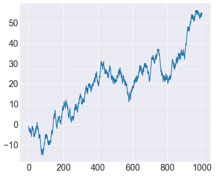

```python
plt.plot(np.cumsum(steps))
```

#### Variance versus time

```python
set100_rw = [np.cumsum(np.random.choice(step_lengths,size=1000)) for _ in range(100)]
```

```
Text(0,0.5,'Position, $x$')
```

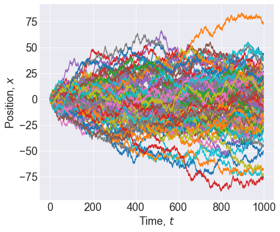

```python
for rw in set100_rw:
    plt.plot(rw)

plt.xlabel('Time, $t$')
plt.ylabel('Position, $x$')
```

```python
np.asarray(set100_rw)
```

```
array([[  1,   0,   1, ...,  -2,  -3,  -2],
       [  1,   2,   3, ...,  74,  73,  72],
       [ -1,   0,   1, ..., -26, -25, -24],
       ...,
       [ -1,   0,   1, ..., -46, -45, -46],
       [ -1,  -2,  -3, ...,  12,  11,  12],
       [ -1,  -2,  -1, ...,  40,  39,  40]])
```

```python
std_vs_time = np.std(np.asarray(set100_rw),axis=0)
```

[figure not shown]

```
Text(0,0.5,'Standard deviation, $\\sigma$')
```

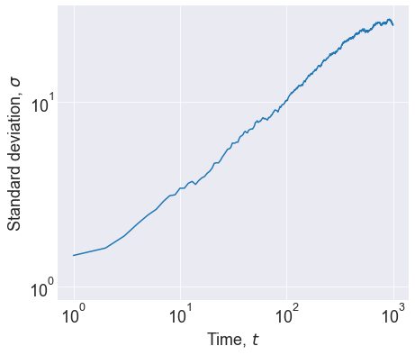

```python
plt.loglog(std_vs_time)
plt.xlabel('Time, $t$')
plt.ylabel('Standard deviation, $\sigma$')
```

We known that $\sigma\sim t^{1/2}$

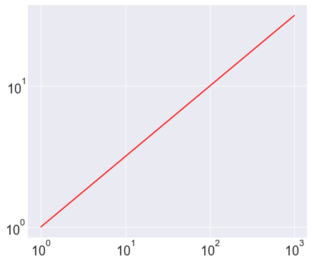

```python
time = np.logspace(0,3)
teo_sigma = time**0.5
plt.loglog(time,teo_sigma,color='red')
```

```
Text(0,0.5,'Standard deviation, $\\sigma$')
```

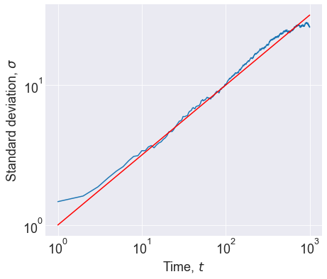

```python
plt.loglog(std_vs_time)
plt.loglog(time,teo_sigma,color='red')
plt.xlabel('Time, $t$')
plt.ylabel('Standard deviation, $\sigma$')
```

### Broadcasting

- Basic operations on numpy arrays (addition, etc.) are elementwise
- This works on arrays of the same size.

*Nevertheless*, It’s also possible to do operations on arrays of different sizes if NumPy can transform these arrays so that they all have the same size: this conversion is called broadcasting.

The image below gives an example of broadcasting:

[figure not shown]

**Let’s verify:**

```python
np.tile
```